# WGCNA 共表达网络分析实战

陈同

28 August, 2023

## 检查有无缺失的包并安装，加载所有包

```r
site = "https://mirrors.tuna.tsinghua.edu.cn/CRAN"

if (!requireNamespace("BiocManager", quietly = TRUE))
  install.packages("BiocManager", repos = site)

a = rownames(installed.packages())

options(BioC_mirror="https://mirrors.tuna.tsinghua.edu.cn/bioconductor")

install_bioc <-
  c(
    "AnnotationDbi", "impute","GO.db", "preprocessCore",
    "WGCNA",
    "dplyr",
    "ggplot2",
    "reshape2",
    "stringr",
    "aplot",
    "pheatmap",
    "conflicted",
    "RColorBrewer"
  )

for (i in install_bioc) {
  if (!i %in% a){
    BiocManager::install(i, update = F, site_repository=site)
    a = rownames(installed.packages())
  }
}

if (!"ImageGP" %in% a){
  # devtools::install_github("Tong-Chen/ImageGP")
  devtools::install_git("https://gitee.com/ct5869/ImageGP.git")
}
```

```r
library(WGCNA)
library(ggplot2)
library(reshape2)
library(stringr)
library(ImageGP)
library(aplot)
library(pheatmap)
library(grid)
library(RColorBrewer)
library(conflicted)

conflict_prefer("cor", "WGCNA")
conflict_prefer("bicor", "WGCNA")

options(stringsAsFactors = FALSE)

if (Sys.info()['sysname'] == "Linux"){
  # 打开多线程
  enableWGCNAThreads()
} else {
# if mac
  allowWGCNAThreads()
}
```

```
## Allowing multi-threading with up to 8 threads.
```

### 准备输入文件

```r
# 格式如前面描述
# 常规表达矩阵，log2转换后或
# Deseq2的varianceStabilizingTransformation转换的数据
# 如果有批次效应，需要事先移除，可使用removeBatchEffect
# 如果有系统偏移(可用boxplot查看基因表达分布是否一致)，
# 需要quantile normalization
exprMat <- "33_WGCNA/LiverFemaleClean.txt"

# 如果没有，设置为空
# traitData <- NULL
traitData <- "33_WGCNA/TraitsClean.txt"

dir.create("result/WGCNA")

output_prefix <- "result/WGCNA/ehbio"


minModuleSize=30
RsquaredCut=0.8
corType = "bicor"
networkType = "signed"
```

### 读入数据并检查其质量

基因表达矩阵: 常规表达矩阵即可，即基因在行，样品在列，进入分析前做一个转置。RPKM、FPKM或其它标准化方法影响不大，推荐使用Deseq2的`varianceStabilizingTransformation`或`log2(x+1)`对标准化后的数据做个转换。

如果数据来自不同的批次，需要先移除批次效应。如果数据存在系统偏移，需要做下`quantile normalization`。

```r
wgcnaL <- WGCNA_readindata(exprMat, traitData)
```

```
## [2023-08-28 15:58:23.791532] Start reading in exprMat and traitData.
## [2023-08-28 15:58:23.979938] Finish reading in exprMat and traitData.
```

```
## [2023-08-28 15:58:23.982342] Start checking data distribution of input matrix.
```

```
## [2023-08-28 15:58:29.760713] End checking data distribution of input matrix.
```

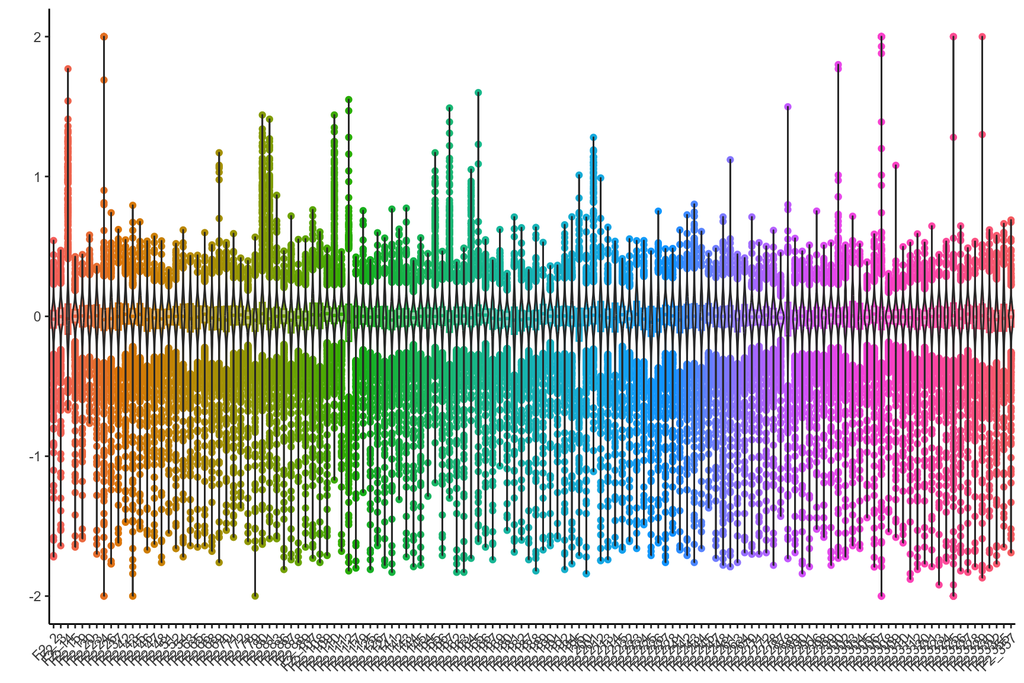

```r
datExpr <- wgcnaL$datExpr


WGCNA_dataCheck(datExpr, saveplot=paste0(output_prefix, ".WGCNA_dataCheck.pdf"), width=20)
```

```r
# WGCNA_dataCheck(datExpr, width=20)
```

### 数据过滤

数据按MAD值排序，可以选择保留前75% (默认)或前10000个用于后续分析。

```r
datExpr <- WGCNA_dataFilter(datExpr, top_mad_n=1)
```

```
## [2023-08-28 15:58:35.990463] Start filtering data.
##  Flagging genes and samples with too many missing values...
##   ..step 1
## [2023-08-28 15:58:36.502875] After filtering, 3600 genes x 134 samples remained.
```

```
## [2023-08-28 15:58:36.504336] Detect outlier samples.
##  Threshold for detecting outlier samples are -2.5
```

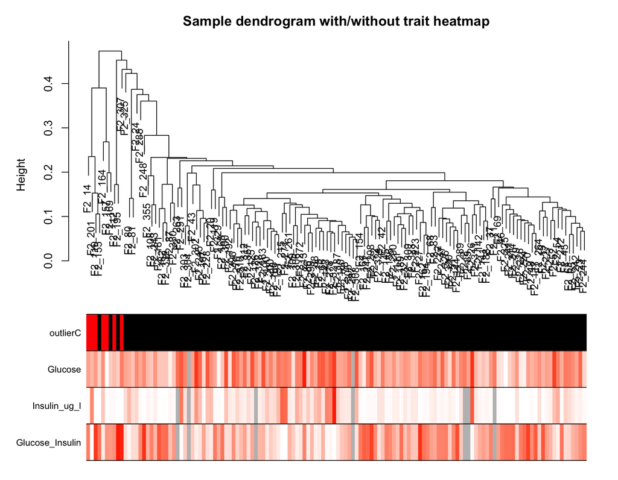

```
##  Removing outlier samples < F2_14 F2_110 F2_112 F2_157 F2_164 F2_201 F2_307 >.
##  After removing outlier samples,  127 samples kept.
## [2023-08-28 15:58:36.729559] Finish detecting outlier samples.
```

```r
# 如果没有表型数据，使用下面这句命令
# datExpr <- WGCNA_sampleClusterDetectOutlier(datExpr)

# datExpr <- WGCNA_sampleClusterDetectOutlier(datExpr, traitColors=wgcnaL$traitColorstaobao, saveplot=paste0(output_prefix, ".WGCNA_sampleClusterDetectOutlier.pdf")
datExpr <- WGCNA_sampleClusterDetectOutlier(datExpr, traitColors=wgcnaL$traitColors, removeOutlier = T)
```

### 筛选合适的软阈值 (soft power)

```r
# power <- WGCNA_softpower(datExpr, saveplot="33_WGCNA/WGCNA_softpower.pdf")
powerList <- WGCNA_softpower(datExpr, RsquaredCut=RsquaredCut, networkType=networkType, saveplot=paste0(output_prefix, ".power.pdf"))
```

```
## [2023-08-28 15:58:36.849503] Select soft power for network construction.
##  Max power used for selection is 45 .
## pickSoftThreshold: will use block size 3600.
##  pickSoftThreshold: calculating connectivity for given powers...
##    ..working on genes 1 through 3600 of 3600
##    Power SFT.R.sq  slope truncated.R.sq  mean.k. median.k. max.k.
## 1      1  0.00313  1.200          0.834 1830.000  1.83e+03 2000.0
## 2      2  0.05450 -2.410          0.858  995.000  1.00e+03 1180.0
## 3      3  0.20300 -3.260          0.865  571.000  5.80e+02  754.0
## 4      4  0.19000 -1.960          0.843  345.000  3.51e+02  503.0
## 5      5  0.15600 -1.200          0.834  219.000  2.20e+02  349.0
## 6      6  0.18100 -0.999          0.832  144.000  1.44e+02  255.0
## 7      7  0.24400 -1.020          0.815   98.800  9.62e+01  195.0
## 8      8  0.33700 -0.810          0.966   70.000  6.61e+01  153.0
## 9      9  0.49000 -0.985          0.983   51.100  4.64e+01  129.0
```

[output cut: 19 more lines]

```
## [2023-08-28 15:58:44.08731] Finished selecting soft power for network construction.
```

```r
power = powerList$power
p = powerList$p
print(paste0("The selected power is ", power))
```

```
## [1] "The selected power is 14"
```

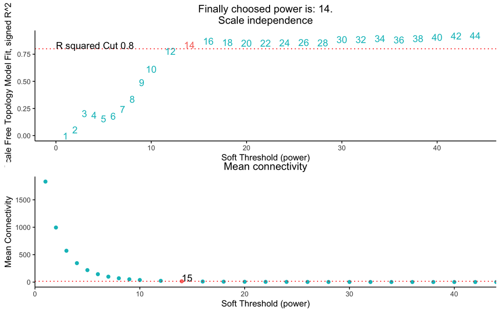

```r
print(p)
```

### 共表达网络构建

如果提示中出现`无法打开压缩文件.Rdata`类似的提示，不是错误，是第一次运行还没有生成计算好的相似性矩阵。如果是第二次及以后运行，程序会自己读取之前计算好的结果，加快运行速度。

```r
set.seed(508)
net <- WGCNA_coexprNetwork(datExpr, power, minModuleSize=minModuleSize, corType = corType, networkType = networkType)
```

```
## [2023-08-28 15:58:44.480212] Start constructing WGCNA network.
##  Calculating module eigengenes block-wise from all genes
##    Flagging genes and samples with too many missing values...
##     ..step 1
##  ..Working on block 1 .
##    ..loading TOM for block 1 from file blockwiseTOM-block.1.RData
## Loading of TOM in block 1 failed:
##  file blockwiseTOM-block.1.RData
##   either does not exist or does not contain the object 'TOM'.
##   Will recalculate TOM.
##     TOM calculation: adjacency..
##     ..will use 8 parallel threads.
##      Fraction of slow calculations: 0.000000
##     ..connectivity..
##     ..matrix multiplication (system BLAS)..
##     ..normalization..
##     ..done.
##    ..saving TOM for block 1 into file blockwiseTOM-block.1.RData
##  ....clustering..
##  ....detecting modules..
##  ....calculating module eigengenes..
##  ....checking kME in modules..
##      ..removing 47 genes from module 1 because their KME is too low.
##      ..removing 25 genes from module 2 because their KME is too low.
##      ..removing 13 genes from module 3 because their KME is too low.
##      ..removing 52 genes from module 4 because their KME is too low.
##      ..removing 4 genes from module 5 because their KME is too low.
##      ..removing 4 genes from module 6 because their KME is too low.
##      ..removing 7 genes from module 7 because their KME is too low.
##      ..removing 22 genes from module 8 because their KME is too low.
##      ..removing 2 genes from module 9 because their KME is too low.
##      ..removing 2 genes from module 10 because their KME is too low.
##      ..removing 4 genes from module 11 because their KME is too low.
##      ..removing 1 genes from module 12 because their KME is too low.
##      ..removing 1 genes from module 13 because their KME is too low.
##      ..removing 1 genes from module 14 because their KME is too low.
##      ..removing 2 genes from module 16 because their KME is too low.
##   ..reassigning 34 genes from module 1 to modules with higher KME.
##   ..reassigning 7 genes from module 2 to modules with higher KME.
##   ..reassigning 2 genes from module 3 to modules with higher KME.
##   ..reassigning 22 genes from module 4 to modules with higher KME.
##   ..reassigning 1 genes from module 5 to modules with higher KME.
##   ..reassigning 3 genes from module 8 to modules with higher KME.
##   ..reassigning 4 genes from module 9 to modules with higher KME.
##   ..reassigning 3 genes from module 10 to modules with higher KME.
##  ..merging modules that are too close..
##      mergeCloseModules: Merging modules whose distance is less than 0.2
##        Calculating new MEs...
##  Core parameters for constructing WGCNA network:
##      power = 14
##      minModuleSize = 30
##      networkType = signed
##      mergeCutHeight = 0.2
##      deepSplit = 1
```

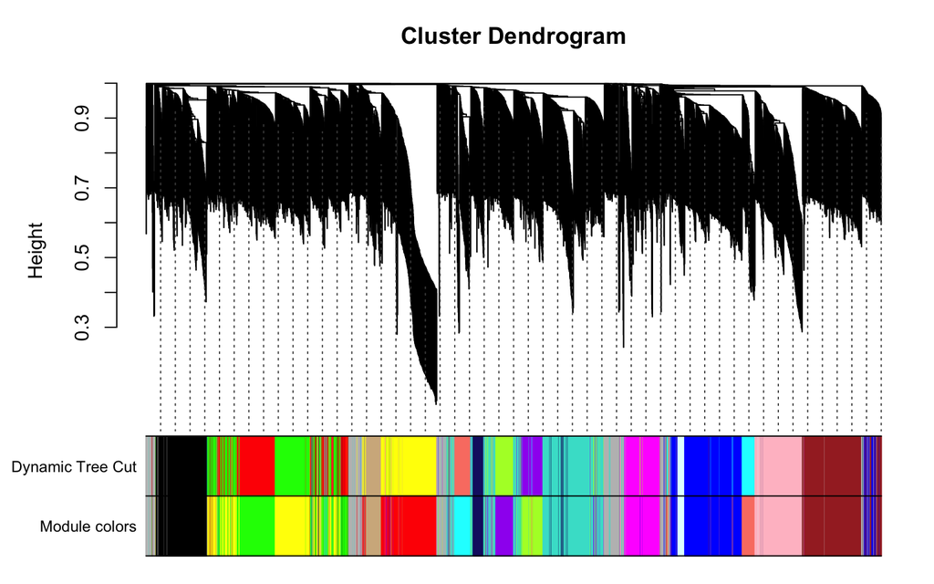

```
## [2023-08-28 15:59:19.188103] Finished constructing WGCNA network.
```

```r
# net <- WGCNA_coexprNetwork(datExpr, power, networkType = "unsigned")
# net <- WGCNA_coexprNetwork(datExpr, power, saveplot=paste0(output_prefix, "WGCNA_module_generation_plot.pdf"))
```

### 存储共表达模块

存储基因共表达模块并绘制模块间相似性热土。

```
## [2023-08-28 15:59:19.423437] Save WGCNA modules.
```

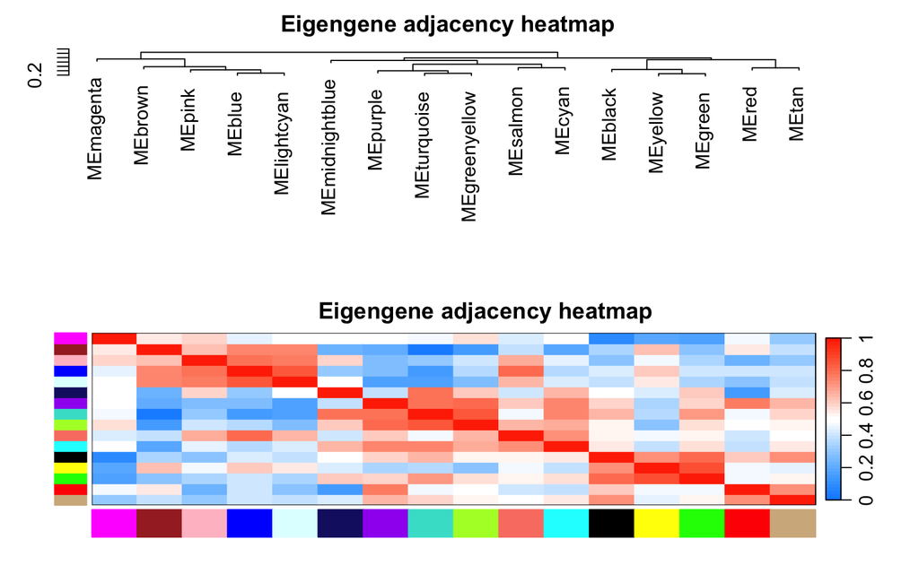

```
## [2023-08-28 15:59:19.458509] Finished saving WGCNA modules.
```

```r
# MEs_col <- WGCNA_saveModuleAndMe(net, datExpr,  prefix=output_prefix，
# saveplot=paste0(output_prefix, ".WGCNA_module_correlation_plot.pdf")
MEs_col <- WGCNA_saveModuleAndMe(net, datExpr, prefix=output_prefix)
```

### 模块和性状关联热图

```
## [2023-08-28 15:59:19.525661] Plot correlation heatmap among all traits and modules.
```

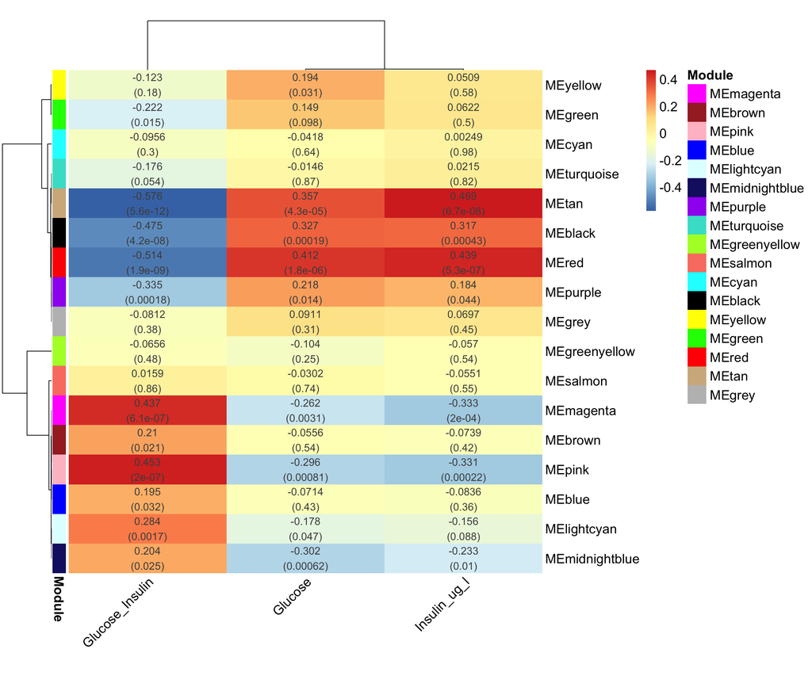

```
## [2023-08-28 15:59:19.600492] Finish plotting correlation heatmap among all traits and modules.
```

```r
# wgcnaL$traitData = WGCNA_filterTrait(datExpr, wgcnaL$traitData)
# wgcnaL$traitColors = WGCNA_filterTrait(datExpr, wgcnaL$traitColors)
# WGCNA_moduleTraitPlot(MEs_col, traitData=wgcnaL$traitData, saveplot="33_WGCNA/WGCNA_moduleTraitHeatmap.pdf", width=15, height=12)
WGCNA_moduleTraitPlot(MEs_col, traitData=wgcnaL$traitData, prefix = output_prefix, corType=corType)
```

### 模块的基因与性状相关性热图

```
## [2023-08-28 15:59:19.781577] Plot module-gene-trait correlation heatmap.
```

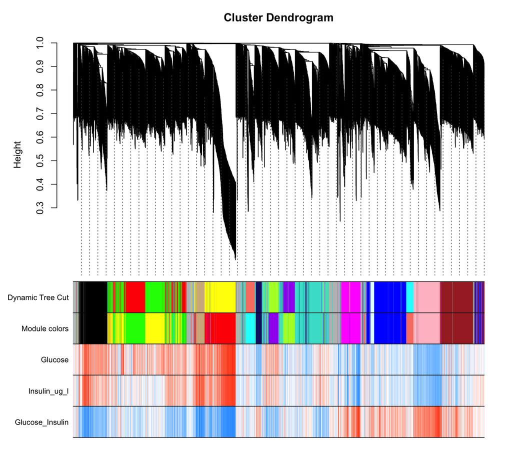

```
## [2023-08-28 15:59:20.351133] Finish plotting module-gene-trait correlation heatmap.
```

```r
# geneTraitCor <- WGCNA_ModuleGeneTraitHeatmap(datExpr, traitData=wgcnaL$traitData, net=net, saveplot=paste0(output_prefix, ".WGCNA_ModuleGeneTraitHeatmap.pdf"))
geneTraitCor <- WGCNA_ModuleGeneTraitHeatmap(datExpr, traitData=wgcnaL$traitData, net=net, prefix = output_prefix, corType=corType)
```

### WGCNA导出Cytoscape网络图数据和鉴定Hub gene

`ehbio.hubgenes.edges.txt`和`ehbio.hubgenes.txt`分别是构建Hub gene网络的网络文件和边文件。

```r
cyt <- WGCNA_cytoscape(net, power, datExpr, prefix=output_prefix)
```

```
## [2023-08-28 15:59:20.787853] Start generating input files for cytoscape.
##  Load TOM similarity matrix.
## Loading objects:
##   TOM
## [2023-08-28 15:59:26.704924] Finish generating input files for cytoscape.
```

```r
hubgene <- WGCNA_hubgene(cyt, top_hub_n=20, prefix=output_prefix)
```

```
## [2023-08-28 15:59:26.706549] Get top hub genes for each module.
## [2023-08-28 15:59:27.550925] Finish outputing top hub genes for each module.
```

```r
# 每个模块展示最核心的两个基因
library(dplyr)
hubgene %>% group_by(Module1) %>% top_n(2)
```

| Node1 | Module1 | weight |
| --- | --- | --- |
| MMT00066001 | black | 21.782546 |
| MMT00052927 | black | 21.712027 |
| MMT00005744 | blue | 44.436002 |
| MMT00082034 | blue | 39.284493 |
| MMT00061093 | brown | 28.293285 |
| MMT00006539 | brown | 27.744539 |
| MMT00076726 | cyan | 10.860170 |
| MMT00053716 | cyan | 10.011368 |
| MMT00037643 | green | 21.850361 |
| MMT00014774 | green | 20.877828 |

[output cut: 22 more lines]

### 筛选Marker基因

遍历每一个模块和性状，寻找与模块和性状都显著相关的基因视为Marker基因。结果输出一堆PDF。

```r
WGCNA_GeneModuleTraitCoorelation(datExpr, MEs_col, geneTraitCor, traitData=wgcnaL$traitData, net, prefix=output_prefix, corType=corType)
```

```
## [2023-08-28 15:59:27.619777] Plot interest genes for each module-trait combination group.
```

```
## [2023-08-28 15:59:27.778098] Finish plotting interest genes for module (magenta) - trait (Glucose) combination group.
```

```
## [2023-08-28 15:59:27.785517] Finish plotting interest genes for module (magenta) - trait (Insulin_ug_l) combination group.
```

```
## [2023-08-28 15:59:27.794301] Finish plotting interest genes for module (magenta) - trait (Glucose_Insulin) combination group.
```

```
## [2023-08-28 15:59:27.807158] Finish plotting interest genes for module (brown) - trait (Glucose) combination group.
```

```
## [2023-08-28 15:59:27.819086] Finish plotting interest genes for module (brown) - trait (Insulin_ug_l) combination group.
```

```
## [2023-08-28 15:59:27.83084] Finish plotting interest genes for module (brown) - trait (Glucose_Insulin) combination group.
```

```
## [2023-08-28 15:59:27.843363] Finish plotting interest genes for module (pink) - trait (Glucose) combination group.
```

```
## [2023-08-28 15:59:27.853296] Finish plotting interest genes for module (pink) - trait (Insulin_ug_l) combination group.
```

```
## [2023-08-28 15:59:27.863404] Finish plotting interest genes for module (pink) - trait (Glucose_Insulin) combination group.
```

```
## [2023-08-28 15:59:27.877609] Finish plotting interest genes for module (blue) - trait (Glucose) combination group.
```

```
## [2023-08-28 15:59:27.891075] Finish plotting interest genes for module (blue) - trait (Insulin_ug_l) combination group.
```

```
## [2023-08-28 15:59:27.90394] Finish plotting interest genes for module (blue) - trait (Glucose_Insulin) combination group.
```

```
## [2023-08-28 15:59:27.908916] Finish plotting interest genes for module (lightcyan) - trait (Glucose) combination group.
```

```
## [2023-08-28 15:59:27.913213] Finish plotting interest genes for module (lightcyan) - trait (Insulin_ug_l) combination group.
```

```
## [2023-08-28 15:59:27.917654] Finish plotting interest genes for module (lightcyan) - trait (Glucose_Insulin) combination group.
```

```
## [2023-08-28 15:59:27.923231] Finish plotting interest genes for module (midnightblue) - trait (Glucose) combination group.
```

```
## [2023-08-28 15:59:27.928047] Finish plotting interest genes for module (midnightblue) - trait (Insulin_ug_l) combination group.
```

```
## [2023-08-28 15:59:27.932764] Finish plotting interest genes for module (midnightblue) - trait (Glucose_Insulin) combination group.
```

```
## [2023-08-28 15:59:27.938802] Finish plotting interest genes for module (purple) - trait (Glucose) combination group.
```

```
## [2023-08-28 15:59:27.944704] Finish plotting interest genes for module (purple) - trait (Insulin_ug_l) combination group.
```

```
## [2023-08-28 15:59:27.9515] Finish plotting interest genes for module (purple) - trait (Glucose_Insulin) combination group.
```

```
## [2023-08-28 15:59:27.967952] Finish plotting interest genes for module (turquoise) - trait (Glucose) combination group.
```

```
## [2023-08-28 15:59:27.990074] Finish plotting interest genes for module (turquoise) - trait (Insulin_ug_l) combination group.
```

```
## [2023-08-28 15:59:28.006252] Finish plotting interest genes for module (turquoise) - trait (Glucose_Insulin) combination group.
```

```
## [2023-08-28 15:59:28.01266] Finish plotting interest genes for module (greenyellow) - trait (Glucose) combination group.
```

```
## [2023-08-28 15:59:28.020948] Finish plotting interest genes for module (greenyellow) - trait (Insulin_ug_l) combination group.
```

```
## [2023-08-28 15:59:28.027209] Finish plotting interest genes for module (greenyellow) - trait (Glucose_Insulin) combination group.
```

```
## [2023-08-28 15:59:28.032426] Finish plotting interest genes for module (salmon) - trait (Glucose) combination group.
```

```
## [2023-08-28 15:59:28.037436] Finish plotting interest genes for module (salmon) - trait (Insulin_ug_l) combination group.
```

```
## [2023-08-28 15:59:28.04302] Finish plotting interest genes for module (salmon) - trait (Glucose_Insulin) combination group.
```

```
## [2023-08-28 15:59:28.048045] Finish plotting interest genes for module (cyan) - trait (Glucose) combination group.
```

```
## [2023-08-28 15:59:28.05278] Finish plotting interest genes for module (cyan) - trait (Insulin_ug_l) combination group.
```

```
## [2023-08-28 15:59:28.058348] Finish plotting interest genes for module (cyan) - trait (Glucose_Insulin) combination group.
```

```
## [2023-08-28 15:59:28.068022] Finish plotting interest genes for module (black) - trait (Glucose) combination group.
```

```
## [2023-08-28 15:59:28.078326] Finish plotting interest genes for module (black) - trait (Insulin_ug_l) combination group.
```

```
## [2023-08-28 15:59:28.088623] Finish plotting interest genes for module (black) - trait (Glucose_Insulin) combination group.
```

```
## [2023-08-28 15:59:28.102504] Finish plotting interest genes for module (yellow) - trait (Glucose) combination group.
```

```
## [2023-08-28 15:59:28.115809] Finish plotting interest genes for module (yellow) - trait (Insulin_ug_l) combination group.
```

```
## [2023-08-28 15:59:28.135782] Finish plotting interest genes for module (yellow) - trait (Glucose_Insulin) combination group.
```

```
## [2023-08-28 15:59:28.151063] Finish plotting interest genes for module (green) - trait (Glucose) combination group.
```

```
## [2023-08-28 15:59:28.164175] Finish plotting interest genes for module (green) - trait (Insulin_ug_l) combination group.
```

```
## [2023-08-28 15:59:28.179285] Finish plotting interest genes for module (green) - trait (Glucose_Insulin) combination group.
```

```
## [2023-08-28 15:59:28.191791] Finish plotting interest genes for module (red) - trait (Glucose) combination group.
```

```
## [2023-08-28 15:59:28.203014] Finish plotting interest genes for module (red) - trait (Insulin_ug_l) combination group.
```

```
## [2023-08-28 15:59:28.214204] Finish plotting interest genes for module (red) - trait (Glucose_Insulin) combination group.
```

```
## [2023-08-28 15:59:28.220078] Finish plotting interest genes for module (tan) - trait (Glucose) combination group.
```

```
## [2023-08-28 15:59:28.225625] Finish plotting interest genes for module (tan) - trait (Insulin_ug_l) combination group.
```

```
## [2023-08-28 15:59:28.238771] Finish plotting interest genes for module (tan) - trait (Glucose_Insulin) combination group.
```